# Case Study: How does a bike-share navigate speedy success?

*This Case study is part of Google Data Analytics Professional Certificate : Capstone Project.

# Scenario

Chicago based Cyclist bike-share company Marketing team needs to design new marketing strategies with a goal of converting casual riders into annual members. In order to do that, however, the marketing analyst team needs to better understand how annual members and casual riders differ.

**Key Stakeholders:**  
* **Lily Moreno:** Director of Marketing  
* **Cyclistic executive team:** Team that will approve recommended marketing strategies.

## ASK

1. **Business task:**
- The key business task is to identify **how the casual members and annual members of Cyclistic are using their rides** and design marketing strategies aiming to convert casual riders into annual members.

## PREPARE

- **Data Source:** 12 months of data (Oct 2020 - Sep 2021) has been downloaded from [Motivate International Inc.](https://divvy-tripdata.s3.amazonaws.com/index.html) under this [license](https://www.divvybikes.com/data-license-agreement).
- **Data Organization and credibility** A total of 12 datasets have been made available for each month starting from October 2020 to September 2021. Each dataset captures the details of every ride logged by the customers of Cyclistic. This data that has been made publicly available has been scrubbed to omit rider’s personal information.

Documentation, Cleaning and Preparation of data for analysis The combined size of all the 12 datasets is close to 1 GB. Data cleaning in spreadsheets will be time-consuming and slow compared to SQL or R. I am choosing R simply because I could do both data wrangling and analysis/ visualizations in the same platform. It is also an opportunity for me to learn R better.

| Field name | Description |
| --- | --- |
| ride_id | A possible Primary Key |
| rideable_type | Type of bike: classic_bike, docked_bike, electric_bi |
| started_at | start date of the ride. Format yyyy-mm-dd hh:mm:ss |
| ended_at | end date of the ride. Format yyyy-mm-dd hh:mm:ss |
| start_station_name | start station name |
| start_station_id | start station id |
| end_station_name | end station name |
| end_station_id | end station id |
| start_lat | start latitude |
| start_lng | start longitude |
| end_lat | end latitude |
| end_lng | end longitude |
| member_casual | Casual/member |

## PROCESS

- **Choose your tools** We will be using R studio to import, clean and analyze the data.

```r
setwd("F:/Case Study/1_Cyclist/1_CSV_Files")
# CSV_Files is the folder name , contains all updated 12 csv files
```

```r
#Load Required Libraries
library(tidyverse)
library(dplyr)
library(data.table)
library(directlabels)
library(ggplot2)
library(lubridate)
library(janitor)
library(skimr)
library(scales)
library(tidyr)
```

- **Load all 12 csv files.**

```r
tp_1_202010 <- read.csv("202010-divvy-tripdata.csv")
tp_2_202011 <- read.csv("202011-divvy-tripdata.csv")
tp_3_202012 <- read.csv("202012-divvy-tripdata.csv")
tp_4_202101 <- read.csv("202101-divvy-tripdata.csv")
tp_5_202102 <- read.csv("202102-divvy-tripdata.csv")
tp_6_202103 <- read.csv("202103-divvy-tripdata.csv")
tp_7_202104 <- read.csv("202104-divvy-tripdata.csv")
tp_8_202105 <- read.csv("202105-divvy-tripdata.csv")
tp_9_202106 <- read.csv("202106-divvy-tripdata.csv")
tp_10_202107 <- read.csv("202107-divvy-tripdata.csv")
tp_11_202108 <- read.csv("202108-divvy-tripdata.csv")
tp_12_202109 <- read.csv("202109-divvy-tripdata.csv")
```

- **check column name of each files of dataset.**

```r
colnames(tp_1_202010)
```

```
##  [1] "ride_id"            "rideable_type"      "started_at"
##  [4] "ended_at"           "start_station_name" "start_station_id"
##  [7] "end_station_name"   "end_station_id"     "start_lat"
## [10] "start_lng"          "end_lat"            "end_lng"
## [13] "member_casual"
```

```r
colnames(tp_2_202011)
```

```
##  [1] "ride_id"            "rideable_type"      "started_at"
##  [4] "ended_at"           "start_station_name" "start_station_id"
##  [7] "end_station_name"   "end_station_id"     "start_lat"
## [10] "start_lng"          "end_lat"            "end_lng"
## [13] "member_casual"
```

```r
colnames(tp_3_202012)
```

```
##  [1] "ride_id"            "rideable_type"      "started_at"
##  [4] "ended_at"           "start_station_name" "start_station_id"
##  [7] "end_station_name"   "end_station_id"     "start_lat"
## [10] "start_lng"          "end_lat"            "end_lng"
## [13] "member_casual"
```

```r
colnames(tp_4_202101)
```

```
##  [1] "ride_id"            "rideable_type"      "started_at"
##  [4] "ended_at"           "start_station_name" "start_station_id"
##  [7] "end_station_name"   "end_station_id"     "start_lat"
## [10] "start_lng"          "end_lat"            "end_lng"
## [13] "member_casual"
```

```r
colnames(tp_5_202102)
```

```
##  [1] "ride_id"            "rideable_type"      "started_at"
##  [4] "ended_at"           "start_station_name" "start_station_id"
##  [7] "end_station_name"   "end_station_id"     "start_lat"
## [10] "start_lng"          "end_lat"            "end_lng"
## [13] "member_casual"
```

```r
colnames(tp_6_202103)
```

```
##  [1] "ride_id"            "rideable_type"      "started_at"
##  [4] "ended_at"           "start_station_name" "start_station_id"
##  [7] "end_station_name"   "end_station_id"     "start_lat"
## [10] "start_lng"          "end_lat"            "end_lng"
## [13] "member_casual"
```

```r
colnames(tp_7_202104)
```

```
##  [1] "ride_id"            "rideable_type"      "started_at"
##  [4] "ended_at"           "start_station_name" "start_station_id"
##  [7] "end_station_name"   "end_station_id"     "start_lat"
## [10] "start_lng"          "end_lat"            "end_lng"
## [13] "member_casual"
```

```r
colnames(tp_8_202105)
```

```
##  [1] "ride_id"            "rideable_type"      "started_at"
##  [4] "ended_at"           "start_station_name" "start_station_id"
##  [7] "end_station_name"   "end_station_id"     "start_lat"
## [10] "start_lng"          "end_lat"            "end_lng"
## [13] "member_casual"
```

```r
colnames(tp_9_202106)
```

```
##  [1] "ride_id"            "rideable_type"      "started_at"
##  [4] "ended_at"           "start_station_name" "start_station_id"
##  [7] "end_station_name"   "end_station_id"     "start_lat"
## [10] "start_lng"          "end_lat"            "end_lng"
## [13] "member_casual"
```

```r
colnames(tp_10_202107)
```

```
##  [1] "ride_id"            "rideable_type"      "started_at"
##  [4] "ended_at"           "start_station_name" "start_station_id"
##  [7] "end_station_name"   "end_station_id"     "start_lat"
## [10] "start_lng"          "end_lat"            "end_lng"
## [13] "member_casual"
```

```r
colnames(tp_11_202108)
```

```
##  [1] "ride_id"            "rideable_type"      "started_at"
##  [4] "ended_at"           "start_station_name" "start_station_id"
##  [7] "end_station_name"   "end_station_id"     "start_lat"
## [10] "start_lng"          "end_lat"            "end_lng"
## [13] "member_casual"
```

```r
colnames(tp_12_202109)
```

```
##  [1] "ride_id"            "rideable_type"      "started_at"
##  [4] "ended_at"           "start_station_name" "start_station_id"
##  [7] "end_station_name"   "end_station_id"     "start_lat"
## [10] "start_lng"          "end_lat"            "end_lng"
## [13] "member_casual"
```

- **check data structure and data types for all data frames.**

```r
str(tp_1_202010)
```

```
## 'data.frame':    388653 obs. of  13 variables:
##  $ ride_id           : chr  "ACB6B40CF5B9044C" "DF450C72FD109C01" "B6396B54A15AC0DF" "44A4AEE261B9E854" ...
##  $ rideable_type     : chr  "electric_bike" "electric_bike" "electric_bike" "electric_bike" ...
##  $ started_at        : chr  "2020-10-31 19:39:43" "2020-10-31 23:50:08" "2020-10-31 23:00:01" "2020-10-31 22:16:43" ...
##  $ ended_at          : chr  "2020-10-31 19:57:12" "2020-11-01 00:04:16" "2020-10-31 23:08:22" "2020-10-31 22:19:35" ...
##  $ start_station_name: chr  "Lakeview Ave & Fullerton Pkwy" "Southport Ave & Waveland Ave" "Stony Island Ave & 67th St" "Clark St & Grace St" ...
##  $ start_station_id  : int  313 227 102 165 190 359 313 125 NA 174 ...
##  $ end_station_name  : chr  "Rush St & Hubbard St" "Kedzie Ave & Milwaukee Ave" "University Ave & 57th St" "Broadway & Sheridan Rd" ...
##  $ end_station_id    : int  125 260 423 256 185 53 125 313 199 635 ...
##  $ start_lat         : num  41.9 41.9 41.8 42 41.9 ...
##  $ start_lng         : num  -87.6 -87.7 -87.6 -87.7 -87.7 ...
##  $ end_lat           : num  41.9 41.9 41.8 42 41.9 ...
##  $ end_lng           : num  -87.6 -87.7 -87.6 -87.7 -87.7 ...
##  $ member_casual     : chr  "casual" "casual" "casual" "casual" ...
```

```r
str(tp_2_202011)
```

```
## 'data.frame':    259716 obs. of  13 variables:
##  $ ride_id           : chr  "BD0A6FF6FFF9B921" "96A7A7A4BDE4F82D" "C61526D06582BDC5" "E533E89C32080B9E" ...
##  $ rideable_type     : chr  "electric_bike" "electric_bike" "electric_bike" "electric_bike" ...
##  $ started_at        : chr  "2020-11-01 13:36:00" "2020-11-01 10:03:26" "2020-11-01 00:34:05" "2020-11-01 00:45:16" ...
##  $ ended_at          : chr  "2020-11-01 13:45:40" "2020-11-01 10:14:45" "2020-11-01 01:03:06" "2020-11-01 00:54:31" ...
##  $ start_station_name: chr  "Dearborn St & Erie St" "Franklin St & Illinois St" "Lake Shore Dr & Monroe St" "Leavitt St & Chicago Ave" ...
##  $ start_station_id  : int  110 672 76 659 2 72 76 NA 58 394 ...
##  $ end_station_name  : chr  "St. Clair St & Erie St" "Noble St & Milwaukee Ave" "Federal St & Polk St" "Stave St & Armitage Ave" ...
##  $ end_station_id    : int  211 29 41 185 2 76 72 NA 288 273 ...
##  $ start_lat         : num  41.9 41.9 41.9 41.9 41.9 ...
##  $ start_lng         : num  -87.6 -87.6 -87.6 -87.7 -87.6 ...
##  $ end_lat           : num  41.9 41.9 41.9 41.9 41.9 ...
##  $ end_lng           : num  -87.6 -87.7 -87.6 -87.7 -87.6 ...
##  $ member_casual     : chr  "casual" "casual" "casual" "casual" ...
```

```r
str(tp_3_202012)
```

```
## 'data.frame':    131573 obs. of  13 variables:
##  $ ride_id           : chr  "70B6A9A437D4C30D" "158A465D4E74C54A" "5262016E0F1F2F9A" "BE119628E44F871E" ...
##  $ rideable_type     : chr  "classic_bike" "electric_bike" "electric_bike" "electric_bike" ...
##  $ started_at        : chr  "2020-12-27 12:44:29" "2020-12-18 17:37:15" "2020-12-15 15:04:33" "2020-12-15 15:54:18" ...
##  $ ended_at          : chr  "2020-12-27 12:55:06" "2020-12-18 17:44:19" "2020-12-15 15:11:28" "2020-12-15 16:00:11" ...
##  $ start_station_name: chr  "Aberdeen St & Jackson Blvd" "" "" "" ...
##  $ start_station_id  : chr  "13157" "" "" "" ...
##  $ end_station_name  : chr  "Desplaines St & Kinzie St" "" "" "" ...
##  $ end_station_id    : chr  "TA1306000003" "" "" "" ...
##  $ start_lat         : num  41.9 41.9 41.9 41.9 41.8 ...
##  $ start_lng         : num  -87.7 -87.7 -87.7 -87.7 -87.6 ...
##  $ end_lat           : num  41.9 41.9 41.9 41.9 41.8 ...
##  $ end_lng           : num  -87.6 -87.7 -87.7 -87.7 -87.6 ...
##  $ member_casual     : chr  "member" "member" "member" "member" ...
```

```r
str(tp_4_202101)
```

```
## 'data.frame':    96834 obs. of  13 variables:
##  $ ride_id           : chr  "E19E6F1B8D4C42ED" "DC88F20C2C55F27F" "EC45C94683FE3F27" "4FA453A75AE377DB" ...
##  $ rideable_type     : chr  "electric_bike" "electric_bike" "electric_bike" "electric_bike" ...
##  $ started_at        : chr  "2021-01-23 16:14:19" "2021-01-27 18:43:08" "2021-01-21 22:35:54" "2021-01-07 13:31:13" ...
##  $ ended_at          : chr  "2021-01-23 16:24:44" "2021-01-27 18:47:12" "2021-01-21 22:37:14" "2021-01-07 13:42:55" ...
##  $ start_station_name: chr  "California Ave & Cortez St" "California Ave & Cortez St" "California Ave & Cortez St" "California Ave & Cortez St" ...
##  $ start_station_id  : chr  "17660" "17660" "17660" "17660" ...
##  $ end_station_name  : chr  "" "" "" "" ...
##  $ end_station_id    : chr  "" "" "" "" ...
##  $ start_lat         : num  41.9 41.9 41.9 41.9 41.9 ...
##  $ start_lng         : num  -87.7 -87.7 -87.7 -87.7 -87.7 ...
##  $ end_lat           : num  41.9 41.9 41.9 41.9 41.9 ...
##  $ end_lng           : num  -87.7 -87.7 -87.7 -87.7 -87.7 ...
##  $ member_casual     : chr  "member" "member" "member" "member" ...
```

```r
str(tp_5_202102)
```

```
## 'data.frame':    49622 obs. of  13 variables:
##  $ ride_id           : chr  "89E7AA6C29227EFF" "0FEFDE2603568365" "E6159D746B2DBB91" "B32D3199F1C2E75B" ...
##  $ rideable_type     : chr  "classic_bike" "classic_bike" "electric_bike" "classic_bike" ...
##  $ started_at        : chr  "2021-02-12 16:14:56" "2021-02-14 17:52:38" "2021-02-09 19:10:18" "2021-02-02 17:49:41" ...
##  $ ended_at          : chr  "2021-02-12 16:21:43" "2021-02-14 18:12:09" "2021-02-09 19:19:10" "2021-02-02 17:54:06" ...
##  $ start_station_name: chr  "Glenwood Ave & Touhy Ave" "Glenwood Ave & Touhy Ave" "Clark St & Lake St" "Wood St & Chicago Ave" ...
##  $ start_station_id  : chr  "525" "525" "KA1503000012" "637" ...
##  $ end_station_name  : chr  "Sheridan Rd & Columbia Ave" "Bosworth Ave & Howard St" "State St & Randolph St" "Honore St & Division St" ...
##  $ end_station_id    : chr  "660" "16806" "TA1305000029" "TA1305000034" ...
##  $ start_lat         : num  42 42 41.9 41.9 41.8 ...
##  $ start_lng         : num  -87.7 -87.7 -87.6 -87.7 -87.6 ...
##  $ end_lat           : num  42 42 41.9 41.9 41.8 ...
##  $ end_lng           : num  -87.7 -87.7 -87.6 -87.7 -87.6 ...
##  $ member_casual     : chr  "member" "casual" "member" "member" ...
```

```r
str(tp_6_202103)
```

```
## 'data.frame':    228496 obs. of  13 variables:
##  $ ride_id           : chr  "CFA86D4455AA1030" "30D9DC61227D1AF3" "846D87A15682A284" "994D05AA75A168F2" ...
##  $ rideable_type     : chr  "classic_bike" "classic_bike" "classic_bike" "classic_bike" ...
##  $ started_at        : chr  "2021-03-16 08:32:30" "2021-03-28 01:26:28" "2021-03-11 21:17:29" "2021-03-11 13:26:42" ...
##  $ ended_at          : chr  "2021-03-16 08:36:34" "2021-03-28 01:36:55" "2021-03-11 21:33:53" "2021-03-11 13:55:41" ...
##  $ start_station_name: chr  "Humboldt Blvd & Armitage Ave" "Humboldt Blvd & Armitage Ave" "Shields Ave & 28th Pl" "Winthrop Ave & Lawrence Ave" ...
##  $ start_station_id  : chr  "15651" "15651" "15443" "TA1308000021" ...
##  $ end_station_name  : chr  "Stave St & Armitage Ave" "Central Park Ave & Bloomingdale Ave" "Halsted St & 35th St" "Broadway & Sheridan Rd" ...
##  $ end_station_id    : chr  "13266" "18017" "TA1308000043" "13323" ...
##  $ start_lat         : num  41.9 41.9 41.8 42 42 ...
##  $ start_lng         : num  -87.7 -87.7 -87.6 -87.7 -87.7 ...
##  $ end_lat           : num  41.9 41.9 41.8 42 42.1 ...
##  $ end_lng           : num  -87.7 -87.7 -87.6 -87.6 -87.7 ...
##  $ member_casual     : chr  "casual" "casual" "casual" "casual" ...
```

```r
str(tp_7_202104)
```

```
## 'data.frame':    337230 obs. of  13 variables:
##  $ ride_id           : chr  "6C992BD37A98A63F" "1E0145613A209000" "E498E15508A80BAD" "1887262AD101C604" ...
##  $ rideable_type     : chr  "classic_bike" "docked_bike" "docked_bike" "classic_bike" ...
##  $ started_at        : chr  "2021-04-12 18:25:36" "2021-04-27 17:27:11" "2021-04-03 12:42:45" "2021-04-17 09:17:42" ...
##  $ ended_at          : chr  "2021-04-12 18:56:55" "2021-04-27 18:31:29" "2021-04-07 11:40:24" "2021-04-17 09:42:48" ...
##  $ start_station_name: chr  "State St & Pearson St" "Dorchester Ave & 49th St" "Loomis Blvd & 84th St" "Honore St & Division St" ...
##  $ start_station_id  : chr  "TA1307000061" "KA1503000069" "20121" "TA1305000034" ...
##  $ end_station_name  : chr  "Southport Ave & Waveland Ave" "Dorchester Ave & 49th St" "Loomis Blvd & 84th St" "Southport Ave & Waveland Ave" ...
##  $ end_station_id    : chr  "13235" "KA1503000069" "20121" "13235" ...
##  $ start_lat         : num  41.9 41.8 41.7 41.9 41.7 ...
##  $ start_lng         : num  -87.6 -87.6 -87.7 -87.7 -87.7 ...
##  $ end_lat           : num  41.9 41.8 41.7 41.9 41.7 ...
##  $ end_lng           : num  -87.7 -87.6 -87.7 -87.7 -87.7 ...
##  $ member_casual     : chr  "member" "casual" "casual" "member" ...
```

```r
str(tp_8_202105)
```

```
## 'data.frame':    531633 obs. of  13 variables:
##  $ ride_id           : chr  "C809ED75D6160B2A" "DD59FDCE0ACACAF3" "0AB83CB88C43EFC2" "7881AC6D39110C60" ...
##  $ rideable_type     : chr  "electric_bike" "electric_bike" "electric_bike" "electric_bike" ...
##  $ started_at        : chr  "2021-05-30 11:58:15" "2021-05-30 11:29:14" "2021-05-30 14:24:01" "2021-05-30 14:25:51" ...
##  $ ended_at          : chr  "2021-05-30 12:10:39" "2021-05-30 12:14:09" "2021-05-30 14:25:13" "2021-05-30 14:41:04" ...
##  $ start_station_name: chr  "" "" "" "" ...
##  $ start_station_id  : chr  "" "" "" "" ...
##  $ end_station_name  : chr  "" "" "" "" ...
##  $ end_station_id    : chr  "" "" "" "" ...
##  $ start_lat         : num  41.9 41.9 41.9 41.9 41.9 ...
##  $ start_lng         : num  -87.6 -87.6 -87.7 -87.7 -87.7 ...
##  $ end_lat           : num  41.9 41.8 41.9 41.9 41.9 ...
##  $ end_lng           : num  -87.6 -87.6 -87.7 -87.7 -87.7 ...
##  $ member_casual     : chr  "casual" "casual" "casual" "casual" ...
```

```r
str(tp_9_202106)
```

```
## 'data.frame':    729595 obs. of  13 variables:
##  $ ride_id           : chr  "99FEC93BA843FB20" "06048DCFC8520CAF" "9598066F68045DF2" "B03C0FE48C412214" ...
##  $ rideable_type     : chr  "electric_bike" "electric_bike" "electric_bike" "electric_bike" ...
##  $ started_at        : chr  "2021-06-13 14:31:28" "2021-06-04 11:18:02" "2021-06-04 09:49:35" "2021-06-03 19:56:05" ...
##  $ ended_at          : chr  "2021-06-13 14:34:11" "2021-06-04 11:24:19" "2021-06-04 09:55:34" "2021-06-03 20:21:55" ...
##  $ start_station_name: chr  "" "" "" "" ...
##  $ start_station_id  : chr  "" "" "" "" ...
##  $ end_station_name  : chr  "" "" "" "" ...
##  $ end_station_id    : chr  "" "" "" "" ...
##  $ start_lat         : num  41.8 41.8 41.8 41.8 41.8 ...
##  $ start_lng         : num  -87.6 -87.6 -87.6 -87.6 -87.6 ...
##  $ end_lat           : num  41.8 41.8 41.8 41.8 41.8 ...
##  $ end_lng           : num  -87.6 -87.6 -87.6 -87.6 -87.6 ...
##  $ member_casual     : chr  "member" "member" "member" "member" ...
```

```r
str(tp_10_202107)
```

```
## 'data.frame':    822410 obs. of  13 variables:
##  $ ride_id           : chr  "0A1B623926EF4E16" "B2D5583A5A5E76EE" "6F264597DDBF427A" "379B58EAB20E8AA5" ...
##  $ rideable_type     : chr  "docked_bike" "classic_bike" "classic_bike" "classic_bike" ...
##  $ started_at        : chr  "2021-07-02 14:44:36" "2021-07-07 16:57:42" "2021-07-25 11:30:55" "2021-07-08 22:08:30" ...
##  $ ended_at          : chr  "2021-07-02 15:19:58" "2021-07-07 17:16:09" "2021-07-25 11:48:45" "2021-07-08 22:23:32" ...
##  $ start_station_name: chr  "Michigan Ave & Washington St" "California Ave & Cortez St" "Wabash Ave & 16th St" "California Ave & Cortez St" ...
##  $ start_station_id  : chr  "13001" "17660" "SL-012" "17660" ...
##  $ end_station_name  : chr  "Halsted St & North Branch St" "Wood St & Hubbard St" "Rush St & Hubbard St" "Carpenter St & Huron St" ...
##  $ end_station_id    : chr  "KA1504000117" "13432" "KA1503000044" "13196" ...
##  $ start_lat         : num  41.9 41.9 41.9 41.9 41.9 ...
##  $ start_lng         : num  -87.6 -87.7 -87.6 -87.7 -87.7 ...
##  $ end_lat           : num  41.9 41.9 41.9 41.9 41.9 ...
##  $ end_lng           : num  -87.6 -87.7 -87.6 -87.7 -87.7 ...
##  $ member_casual     : chr  "casual" "casual" "member" "member" ...
```

```r
str(tp_11_202108)
```

```
## 'data.frame':    804352 obs. of  13 variables:
##  $ ride_id           : chr  "99103BB87CC6C1BB" "EAFCCCFB0A3FC5A1" "9EF4F46C57AD234D" "5834D3208BFAF1DA" ...
##  $ rideable_type     : chr  "electric_bike" "electric_bike" "electric_bike" "electric_bike" ...
##  $ started_at        : chr  "2021-08-10 17:15:49" "2021-08-10 17:23:14" "2021-08-21 02:34:23" "2021-08-21 06:52:55" ...
##  $ ended_at          : chr  "2021-08-10 17:22:44" "2021-08-10 17:39:24" "2021-08-21 02:50:36" "2021-08-21 07:08:13" ...
##  $ start_station_name: chr  "" "" "" "" ...
##  $ start_station_id  : chr  "" "" "" "" ...
##  $ end_station_name  : chr  "" "" "" "" ...
##  $ end_station_id    : chr  "" "" "" "" ...
##  $ start_lat         : num  41.8 41.8 42 42 41.8 ...
##  $ start_lng         : num  -87.7 -87.7 -87.7 -87.7 -87.6 ...
##  $ end_lat           : num  41.8 41.8 42 42 41.8 ...
##  $ end_lng           : num  -87.7 -87.6 -87.7 -87.7 -87.6 ...
##  $ member_casual     : chr  "member" "member" "member" "member" ...
```

```r
str(tp_12_202109)
```

```
## 'data.frame':    756147 obs. of  13 variables:
##  $ ride_id           : chr  "9DC7B962304CBFD8" "F930E2C6872D6B32" "6EF72137900BB910" "78D1DE133B3DBF55" ...
##  $ rideable_type     : chr  "electric_bike" "electric_bike" "electric_bike" "electric_bike" ...
##  $ started_at        : chr  "2021-09-28 16:07:10" "2021-09-28 14:24:51" "2021-09-28 00:20:16" "2021-09-28 14:51:17" ...
##  $ ended_at          : chr  "2021-09-28 16:09:54" "2021-09-28 14:40:05" "2021-09-28 00:23:57" "2021-09-28 15:00:06" ...
##  $ start_station_name: chr  "" "" "" "" ...
##  $ start_station_id  : chr  "" "" "" "" ...
##  $ end_station_name  : chr  "" "" "" "" ...
##  $ end_station_id    : chr  "" "" "" "" ...
##  $ start_lat         : num  41.9 41.9 41.8 41.8 41.9 ...
##  $ start_lng         : num  -87.7 -87.6 -87.7 -87.7 -87.7 ...
##  $ end_lat           : num  41.9 42 41.8 41.8 41.9 ...
##  $ end_lng           : num  -87.7 -87.7 -87.7 -87.7 -87.7 ...
##  $ member_casual     : chr  "casual" "casual" "casual" "casual" ...
```

- **start_station_id and end_station_id is in inconsistent format. Need to change from int to chr format.**

```r
tp_1_202010 <- tp_1_202010 %>%mutate(start_station_id = as.character(start_station_id), end_station_id = as.character(end_station_id))
tp_2_202011 <- tp_2_202011 %>%mutate(start_station_id = as.character(start_station_id), end_station_id = as.character(end_station_id))
```

- Combined dataset.Delete unncessary column which we don’t want for our analysis.

```r
combined_tripdata <- bind_rows(tp_1_202010, tp_2_202011, tp_3_202012, tp_4_202101, tp_5_202102, tp_6_202103, tp_7_202104, tp_8_202105, tp_9_202106, tp_10_202107, tp_11_202108, tp_12_202109)
```

- **check format of all columns**

```r
str(combined_tripdata)
```

```
## 'data.frame':    5136261 obs. of  13 variables:
##  $ ride_id           : chr  "ACB6B40CF5B9044C" "DF450C72FD109C01" "B6396B54A15AC0DF" "44A4AEE261B9E854" ...
##  $ rideable_type     : chr  "electric_bike" "electric_bike" "electric_bike" "electric_bike" ...
##  $ started_at        : chr  "2020-10-31 19:39:43" "2020-10-31 23:50:08" "2020-10-31 23:00:01" "2020-10-31 22:16:43" ...
##  $ ended_at          : chr  "2020-10-31 19:57:12" "2020-11-01 00:04:16" "2020-10-31 23:08:22" "2020-10-31 22:19:35" ...
##  $ start_station_name: chr  "Lakeview Ave & Fullerton Pkwy" "Southport Ave & Waveland Ave" "Stony Island Ave & 67th St" "Clark St & Grace St" ...
##  $ start_station_id  : chr  "313" "227" "102" "165" ...
##  $ end_station_name  : chr  "Rush St & Hubbard St" "Kedzie Ave & Milwaukee Ave" "University Ave & 57th St" "Broadway & Sheridan Rd" ...
##  $ end_station_id    : chr  "125" "260" "423" "256" ...
##  $ start_lat         : num  41.9 41.9 41.8 42 41.9 ...
##  $ start_lng         : num  -87.6 -87.7 -87.6 -87.7 -87.7 ...
##  $ end_lat           : num  41.9 41.9 41.8 42 41.9 ...
##  $ end_lng           : num  -87.6 -87.7 -87.6 -87.7 -87.7 ...
##  $ member_casual     : chr  "casual" "casual" "casual" "casual" ...
```

```r
glimpse(combined_tripdata)
```

```
## Rows: 5,136,261
## Columns: 13
## $ ride_id            <chr> "ACB6B40CF5B9044C", "DF450C72FD109C01", "B6396B54A1~
## $ rideable_type      <chr> "electric_bike", "electric_bike", "electric_bike", ~
## $ started_at         <chr> "2020-10-31 19:39:43", "2020-10-31 23:50:08", "2020~
## $ ended_at           <chr> "2020-10-31 19:57:12", "2020-11-01 00:04:16", "2020~
## $ start_station_name <chr> "Lakeview Ave & Fullerton Pkwy", "Southport Ave & W~
## $ start_station_id   <chr> "313", "227", "102", "165", "190", "359", "313", "1~
## $ end_station_name   <chr> "Rush St & Hubbard St", "Kedzie Ave & Milwaukee Ave~
## $ end_station_id     <chr> "125", "260", "423", "256", "185", "53", "125", "31~
## $ start_lat          <dbl> 41.92610, 41.94817, 41.77346, 41.95085, 41.92886, 4~
## $ start_lng          <dbl> -87.63898, -87.66391, -87.58537, -87.65924, -87.663~
## $ end_lat            <dbl> 41.89035, 41.92953, 41.79145, 41.95281, 41.91778, 4~
## $ end_lng            <dbl> -87.62607, -87.70782, -87.60005, -87.65010, -87.691~
## $ member_casual      <chr> "casual", "casual", "casual", "casual", "casual", "~
```

- started_at and ended_at column should be in date & time format.
- convert all of them into datetime format from character format.

```r
combined_tripdata[['started_at']] <- ymd_hms(combined_tripdata[['started_at']])
combined_tripdata[['ended_at']] <- ymd_hms(combined_tripdata[['ended_at']])
```

```r
combined_tripdata <- combined_tripdata %>% select(-c(start_lat:end_lng))
str(combined_tripdata)
```

```
## 'data.frame':    5136261 obs. of  9 variables:
##  $ ride_id           : chr  "ACB6B40CF5B9044C" "DF450C72FD109C01" "B6396B54A15AC0DF" "44A4AEE261B9E854" ...
##  $ rideable_type     : chr  "electric_bike" "electric_bike" "electric_bike" "electric_bike" ...
##  $ started_at        : POSIXct, format: "2020-10-31 19:39:43" "2020-10-31 23:50:08" ...
##  $ ended_at          : POSIXct, format: "2020-10-31 19:57:12" "2020-11-01 00:04:16" ...
##  $ start_station_name: chr  "Lakeview Ave & Fullerton Pkwy" "Southport Ave & Waveland Ave" "Stony Island Ave & 67th St" "Clark St & Grace St" ...
##  $ start_station_id  : chr  "313" "227" "102" "165" ...
##  $ end_station_name  : chr  "Rush St & Hubbard St" "Kedzie Ave & Milwaukee Ave" "University Ave & 57th St" "Broadway & Sheridan Rd" ...
##  $ end_station_id    : chr  "125" "260" "423" "256" ...
##  $ member_casual     : chr  "casual" "casual" "casual" "casual" ...
```

```r
glimpse(combined_tripdata)
```

```
## Rows: 5,136,261
## Columns: 9
## $ ride_id            <chr> "ACB6B40CF5B9044C", "DF450C72FD109C01", "B6396B54A1~
## $ rideable_type      <chr> "electric_bike", "electric_bike", "electric_bike", ~
## $ started_at         <dttm> 2020-10-31 19:39:43, 2020-10-31 23:50:08, 2020-10-~
## $ ended_at           <dttm> 2020-10-31 19:57:12, 2020-11-01 00:04:16, 2020-10-~
## $ start_station_name <chr> "Lakeview Ave & Fullerton Pkwy", "Southport Ave & W~
## $ start_station_id   <chr> "313", "227", "102", "165", "190", "359", "313", "1~
## $ end_station_name   <chr> "Rush St & Hubbard St", "Kedzie Ave & Milwaukee Ave~
## $ end_station_id     <chr> "125", "260", "423", "256", "185", "53", "125", "31~
## $ member_casual      <chr> "casual", "casual", "casual", "casual", "casual", "~
```

- **Rename column name for better understading.**

```r
combined_tripdata <- combined_tripdata %>% rename( ride_type = rideable_type, start_time = started_at, end_time = ended_at, consumer_type = member_casual)
glimpse(combined_tripdata)
```

```
## Rows: 5,136,261
## Columns: 9
## $ ride_id            <chr> "ACB6B40CF5B9044C", "DF450C72FD109C01", "B6396B54A1~
## $ ride_type          <chr> "electric_bike", "electric_bike", "electric_bike", ~
## $ start_time         <dttm> 2020-10-31 19:39:43, 2020-10-31 23:50:08, 2020-10-~
## $ end_time           <dttm> 2020-10-31 19:57:12, 2020-11-01 00:04:16, 2020-10-~
## $ start_station_name <chr> "Lakeview Ave & Fullerton Pkwy", "Southport Ave & W~
## $ start_station_id   <chr> "313", "227", "102", "165", "190", "359", "313", "1~
## $ end_station_name   <chr> "Rush St & Hubbard St", "Kedzie Ave & Milwaukee Ave~
## $ end_station_id     <chr> "125", "260", "423", "256", "185", "53", "125", "31~
## $ consumer_type      <chr> "casual", "casual", "casual", "casual", "casual", "~
```

**Add new columns that can be used for aggregate functions**

- **column for the day of the week the trip started.**

```r
combined_tripdata$day_of_the_week <- format(as.Date(combined_tripdata$start_time),'%a')
```

- **column for the month when trip started.**

```r
combined_tripdata$month <- format(as.Date(combined_tripdata$start_time),'%b_%y')
```

```r
combined_tripdata$time <- format(combined_tripdata$start_time, format = "%H:%M")
combined_tripdata$time <- as.POSIXct(combined_tripdata$start_time, format = "%H:%M")
```

- column for trip duration in minute.

```r
combined_tripdata$trip_duration <- (as.double(difftime(combined_tripdata$end_time, combined_tripdata$start_time)))/60
```

- check the updated dataframe.

```r
glimpse(combined_tripdata)
```

[output not shown]

- checking for trip lengths less than zero(0).

```r
nrow(subset(combined_tripdata, trip_duration < 0))
```

[output not shown]

- checking for testrides that were made by company for quality checks.

```r
nrow(subset(combined_tripdata, start_station_name %like% "Test"))
```

```
## [1] 0
```

```r
nrow(subset(combined_tripdata, start_station_name %like% "test"))
```

```
## [1] 0
```

```r
nrow(subset(combined_tripdata, start_station_name %like% "TEST"))
```

```
## [1] 800
```

- REMOVE Negative trip duration from dataset.

```r
combined_tripdata_v2 <- combined_tripdata[!(combined_tripdata$trip_duration < 0),]
```

- Remove test rides.

```r
combined_tripdata_v2 <- combined_tripdata_v2[!(combined_tripdata_v2$start_station_name %like% "TEST"),]
```

- check updated dataframe.

```r
glimpse(combined_tripdata_v2)
```

```
## Rows: 5,132,158
## Columns: 13
## $ ride_id            <chr> "ACB6B40CF5B9044C", "DF450C72FD109C01", "B6396B54A1~
## $ ride_type          <chr> "electric_bike", "electric_bike", "electric_bike", ~
## $ start_time         <dttm> 2020-10-31 19:39:43, 2020-10-31 23:50:08, 2020-10-~
## $ end_time           <dttm> 2020-10-31 19:57:12, 2020-11-01 00:04:16, 2020-10-~
## $ start_station_name <chr> "Lakeview Ave & Fullerton Pkwy", "Southport Ave & W~
## $ start_station_id   <chr> "313", "227", "102", "165", "190", "359", "313", "1~
## $ end_station_name   <chr> "Rush St & Hubbard St", "Kedzie Ave & Milwaukee Ave~
## $ end_station_id     <chr> "125", "260", "423", "256", "185", "53", "125", "31~
## $ consumer_type      <chr> "casual", "casual", "casual", "casual", "casual", "~
## $ day_of_the_week    <chr> "Sat", "Sat", "Sat", "Sat", "Sat", "Thu", "Thu", "T~
## $ month              <chr> "Oct_20", "Oct_20", "Oct_20", "Oct_20", "Oct_20", "~
## $ time               <dttm> 2020-10-31 19:39:43, 2020-10-31 23:50:08, 2020-10-~
## $ trip_duration      <dbl> 17.483333, 14.133333, 8.350000, 2.866667, 16.216667~
```

- checking count of distinct values.

```r
table(combined_tripdata_v2$consumer_type)
```

[output not shown]

- aggregating total trip duration by customer type.

```r
setNames(aggregate(trip_duration ~ consumer_type, combined_tripdata_v2, sum), c("consumer_type", 'total_trip_duration(mins)'))
```

[output not shown]

**4 & 5. Analyze and Share the Data**

- The dataframe is now ready for descriptive analysis that will help us uncover some insights on how the casual riders and members use Cyclistic rideshare differently.
- First, let’s try to get some simple statistics on trip_duration for all consumer, and do the same by consumer_type.
- statictical summary of trip_duration for all trips.

```r
summary(combined_tripdata_v2$trip_duration)
```

```
##     Min.  1st Qu.   Median     Mean  3rd Qu.     Max.
##     0.00     7.10    12.60    22.75    22.82 55944.15
```

**statistical summary of trip_duration by customer_type**

```r
combined_tripdata_v2 %>%
  group_by(consumer_type) %>% summarise(min_trip_duration = min(trip_duration), max_trip_duration = max(trip_duration), median_trip_duration = median(trip_duration), mean_trip_duration = mean(trip_duration))
```

```
## # A tibble: 2 x 5
##   consumer_type min_trip_duration max_trip_duration median_trip_duration
##   <chr>                     <dbl>             <dbl>                <dbl>
## 1 casual                        0            55944.                 16.7
## 2 member                        0             9558.                 10.1
## # ... with 1 more variable: mean_trip_duration <dbl>
```

- **The mean trip duration of member riders is lower than the mean trip duration of casual riders. This tells us that casual riders usually take the bikes out for a longer duration compared to members.**
- Total number of trips by customer type and day of the week.
- fix the order for the day_of_the_week and month variable so that they show up.
- in the same sequence in output tables and visualizations.

```r
combined_tripdata_v2$day_of_the_week <- ordered(combined_tripdata_v2$day_of_the_week, levels = c('Mon', 'Tue', 'Wed', 'Thu', 'Fri', 'Sat', 'Sun'))
combined_tripdata_v2$month <- ordered(combined_tripdata_v2$month, levels = c('Oct_20', 'Nov_20', 'Dec_20', 'Jan_21', 'Feb_21', 'Mar_21', 'Apr_21', 'May_21', 'Jun_21', 'Jul_21', 'Aug_21', 'Sep_21'))
```

- This will show the table. Next will take the graph.

```r
combined_tripdata_v2 %>%
  group_by(consumer_type, day_of_the_week) %>%
  summarise(number_of_rides = n(), `average_duration_mins` = mean(trip_duration)) %>%
  arrange(consumer_type, desc(number_of_rides))
```

```
## # A tibble: 14 x 4
## # Groups:   consumer_type [2]
##    consumer_type day_of_the_week number_of_rides average_duration_mins
##    <chr>         <ord>                     <int>                 <dbl>
##  1 casual        Sat                      523672                  35.6
##  2 casual        Sun                      444948                  38.1
##  3 casual        Fri                      338975                  31.4
##  4 casual        Thu                      274473                  28.4
##  5 casual        Mon                      266291                  32.6
##  6 casual        Wed                      257055                  28.6
##  7 casual        Tue                      251311                  29.3
##  8 member        Wed                      422573                  13.4
##  9 member        Thu                      420314                  13.3
## 10 member        Tue                      406666                  13.3
## 11 member        Fri                      405264                  14.0
## 12 member        Sat                      399883                  15.7
## 13 member        Mon                      375676                  13.7
## 14 member        Sun                      345057                  16.0
```

#skim without chart.

```r
skim_without_charts(combined_tripdata_v2)
```

Data summary

| Name | combined_tripdata_v2 |
| --- | --- |
| Number of rows | 5132158 |
| Number of columns | 13 |
| _______________________ |  |
| Column type frequency: |  |
| character | 7 |
| factor | 2 |
| numeric | 1 |
| POSIXct | 3 |
| ________________________ |  |
| Group variables | None |

**Variable type: character**

| skim_variable | n_missing | complete_rate | min | max | empty | n_unique | whitespace |
| --- | --- | --- | --- | --- | --- | --- | --- |
| ride_id | 0 | 1.00 | 16 | 16 | 0 | 5132158 | 0 |
| ride_type | 0 | 1.00 | 11 | 13 | 0 | 3 | 0 |
| start_station_name | 0 | 1.00 | 0 | 53 | 523409 | 783 | 0 |
| start_station_id | 55834 | 0.99 | 0 | 36 | 467889 | 1298 | 0 |
| end_station_name | 0 | 1.00 | 0 | 53 | 567128 | 781 | 0 |
| end_station_id | 62531 | 0.99 | 0 | 36 | 504830 | 1299 | 0 |
| consumer_type | 0 | 1.00 | 6 | 6 | 0 | 2 | 0 |

**Variable type: factor**

| skim_variable | n_missing | complete_rate | ordered | n_unique | top_counts |
| --- | --- | --- | --- | --- | --- |
| day_of_the_week | 0 | 1 | TRUE | 7 | Sat: 923555, Sun: 790005, Fri: 744239, Thu: 694787 |
| month | 0 | 1 | TRUE | 12 | Jul: 822397, Aug: 804323, Sep: 756111, Jun: 729590 |

**Variable type: numeric**

| skim_variable | n_missing | complete_rate | mean | sd | p0 | p25 | p50 | p75 | p100 |
| --- | --- | --- | --- | --- | --- | --- | --- | --- | --- |
| trip_duration | 0 | 1 | 22.75 | 178.29 | 0 | 7.1 | 12.6 | 22.82 | 55944.15 |

**Variable type: POSIXct**

| skim_variable | n_missing | complete_rate | min | max | median | n_unique |
| --- | --- | --- | --- | --- | --- | --- |
| start_time | 0 | 1 | 2020-10-01 00:00:06 | 2021-09-30 23:59:48 | 2021-06-21 18:47:52 | 4299071 |
| end_time | 0 | 1 | 2020-10-01 00:05:09 | 2021-10-01 22:55:35 | 2021-06-21 19:08:03 | 4288534 |
| time | 0 | 1 | 2020-10-01 00:00:06 | 2021-09-30 23:59:48 | 2021-06-21 18:47:52 | 4299071 |

```r
summary(combined_tripdata_v2)
```

```
##    ride_id           ride_type           start_time
##  Length:5132158     Length:5132158     Min.   :2020-10-01 00:00:06
##  Class :character   Class :character   1st Qu.:2021-04-12 09:40:05
##  Mode  :character   Mode  :character   Median :2021-06-21 18:47:52
##                                        Mean   :2021-05-26 02:26:55
##                                        3rd Qu.:2021-08-11 22:12:16
##                                        Max.   :2021-09-30 23:59:48
##
##     end_time                   start_station_name start_station_id
##  Min.   :2020-10-01 00:05:09   Length:5132158     Length:5132158
##  1st Qu.:2021-04-12 10:01:38   Class :character   Class :character
##  Median :2021-06-21 19:08:03   Mode  :character   Mode  :character
##  Mean   :2021-05-26 02:49:40
##  3rd Qu.:2021-08-11 22:29:28
##  Max.   :2021-10-01 22:55:35
##
##  end_station_name   end_station_id     consumer_type      day_of_the_week
##  Length:5132158     Length:5132158     Length:5132158     Mon:641967
##  Class :character   Class :character   Class :character   Tue:657977
##  Mode  :character   Mode  :character   Mode  :character   Wed:679628
##                                                           Thu:694787
##                                                           Fri:744239
##                                                           Sat:923555
##                                                           Sun:790005
##      month              time                     trip_duration
##  Jul_21 : 822397   Min.   :2020-10-01 00:00:06   Min.   :    0.00
##  Aug_21 : 804323   1st Qu.:2021-04-12 09:40:05   1st Qu.:    7.10
##  Sep_21 : 756111   Median :2021-06-21 18:47:52   Median :   12.60
##  Jun_21 : 729590   Mean   :2021-05-26 02:26:55   Mean   :   22.75
##  May_21 : 531631   3rd Qu.:2021-08-11 22:12:16   3rd Qu.:   22.82
##  Oct_20 : 386048   Max.   :2021-09-30 23:59:48   Max.   :55944.15
##  (Other):1102058
```

- The below code will plot the grah day of the week.

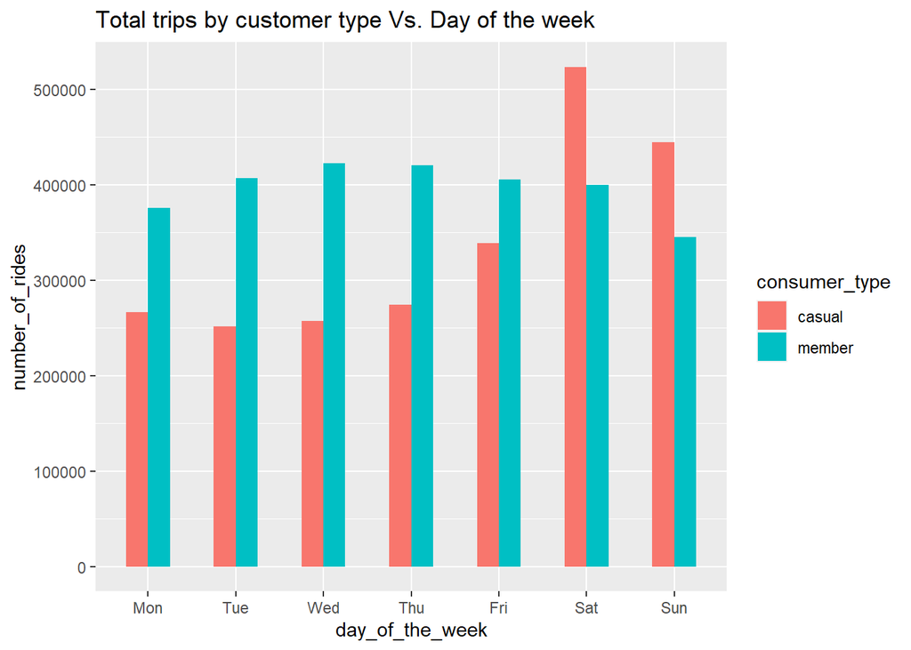

```r
combined_tripdata_v2 %>%
  group_by(consumer_type, day_of_the_week) %>%
  summarise(number_of_rides = n()) %>%
  arrange(consumer_type, day_of_the_week)  %>%
  ggplot(aes(x = day_of_the_week, y = number_of_rides, fill = consumer_type)) +
  labs(title ="Total trips by customer type Vs. Day of the week") +
  geom_col(width=0.5, position = position_dodge(width=0.5)) +
  scale_y_continuous(labels = function(x) format(x, scientific = FALSE))
```

- From the table and graph above, casual riders are most busy on Saturday followed by Sunday, where as there is no signifcant difference observed for member riders during the week.
- Interesting pattern to note though is the consistent trip numbers among members with less spread over entire week as compared to casual riders who don’t seem to use the bikeshare services much during weekdays.
- **Average number of trips by customer type and month.**

```r
unique(combined_tripdata_v2$month)
```

```
##  [1] Oct_20 Nov_20 Dec_20 Jan_21 Feb_21 Mar_21 Apr_21 May_21 Jun_21 Jul_21
## [11] Aug_21 Sep_21
## 12 Levels: Oct_20 < Nov_20 < Dec_20 < Jan_21 < Feb_21 < Mar_21 < ... < Sep_21
```

```r
combined_tripdata_v2 %>%
  group_by(consumer_type, month) %>%
  summarise(number_of_rides = n(), `average_duration_(mins)` = mean(trip_duration)) %>%
  arrange(consumer_type, desc(number_of_rides))
```

```
## # A tibble: 24 x 4
## # Groups:   consumer_type [2]
##    consumer_type month  number_of_rides `average_duration_(mins)`
##    <chr>         <ord>            <int>                     <dbl>
##  1 casual        Jul_21          442048                      32.8
##  2 casual        Aug_21          412662                      28.8
##  3 casual        Jun_21          370678                      37.1
##  4 casual        Sep_21          363883                      27.8
##  5 casual        May_21          256916                      38.2
##  6 casual        Oct_20          143850                      30.4
##  7 casual        Apr_21          136601                      38.0
##  8 casual        Nov_20           87810                      31.9
##  9 casual        Mar_21           84032                      38.2
## 10 casual        Dec_20           29997                      26.8
## # ... with 14 more rows
```

```r
glimpse(combined_tripdata_v2)
```

```
## Rows: 5,132,158
## Columns: 13
## $ ride_id            <chr> "ACB6B40CF5B9044C", "DF450C72FD109C01", "B6396B54A1~
## $ ride_type          <chr> "electric_bike", "electric_bike", "electric_bike", ~
## $ start_time         <dttm> 2020-10-31 19:39:43, 2020-10-31 23:50:08, 2020-10-~
## $ end_time           <dttm> 2020-10-31 19:57:12, 2020-11-01 00:04:16, 2020-10-~
## $ start_station_name <chr> "Lakeview Ave & Fullerton Pkwy", "Southport Ave & W~
## $ start_station_id   <chr> "313", "227", "102", "165", "190", "359", "313", "1~
## $ end_station_name   <chr> "Rush St & Hubbard St", "Kedzie Ave & Milwaukee Ave~
## $ end_station_id     <chr> "125", "260", "423", "256", "185", "53", "125", "31~
## $ consumer_type      <chr> "casual", "casual", "casual", "casual", "casual", "~
## $ day_of_the_week    <ord> Sat, Sat, Sat, Sat, Sat, Thu, Thu, Thu, Wed, Thu, W~
## $ month              <ord> Oct_20, Oct_20, Oct_20, Oct_20, Oct_20, Oct_20, Oct~
## $ time               <dttm> 2020-10-31 19:39:43, 2020-10-31 23:50:08, 2020-10-~
## $ trip_duration      <dbl> 17.483333, 14.133333, 8.350000, 2.866667, 16.216667~
```

- **month vise graphical view.**

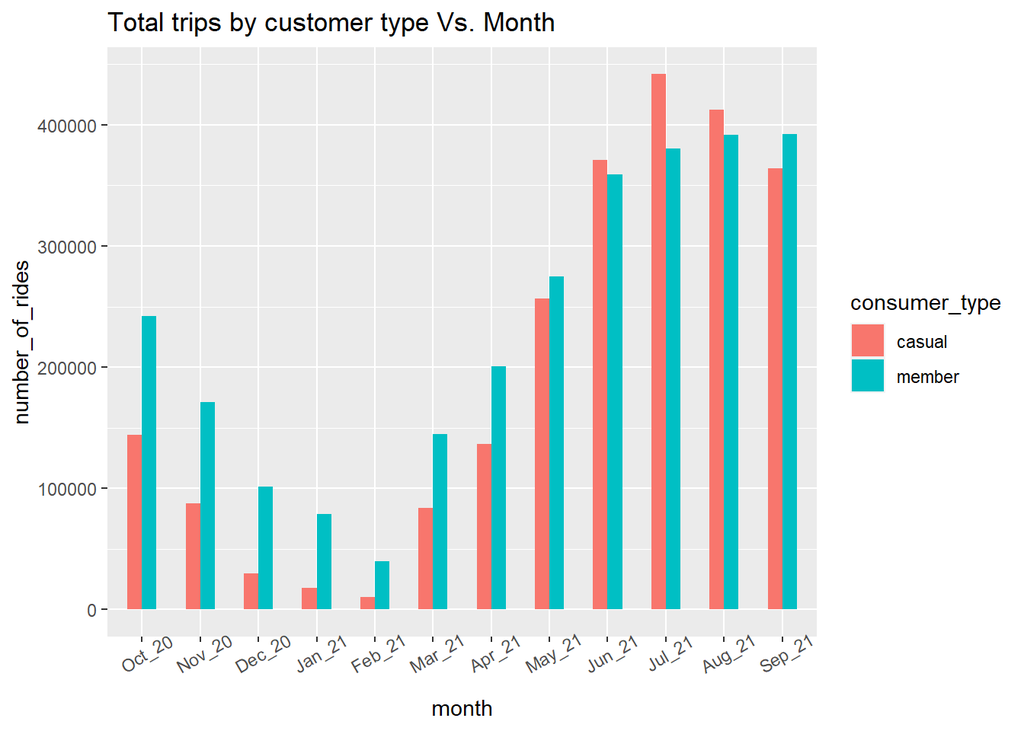

```r
combined_tripdata_v2 %>%
  group_by(consumer_type, month) %>%
  summarise(number_of_rides = n()) %>%
  arrange(consumer_type, month)  %>%
  ggplot(aes(x = month, y = number_of_rides, fill = consumer_type)) +
  labs(title ="Total trips by customer type Vs. Month") +
  theme(axis.text.x = element_text(angle = 30)) +
  geom_col(width=0.5, position = position_dodge(width=0.5)) +
  scale_y_continuous(labels = function(x) format(x, scientific = FALSE))
```

- The data shows from above table and graph, that the months of June, July, August and September are the most busy time of the year among both members and casual riders. This could be attributed to an external factor (eg. cold weather, major quality issue) that might have hindered with customer needs. 2020-2021 is a tough year when Covid comes. People care more about their health. The charts shows that the no.of rides in 2021 is higher than 2020 in general. However, the number of trips made by members is always higher than the casual riders across all months of the year excluding June 21 to August 21.

## Visualizaton of average trip duration by customer type on each day of the week.

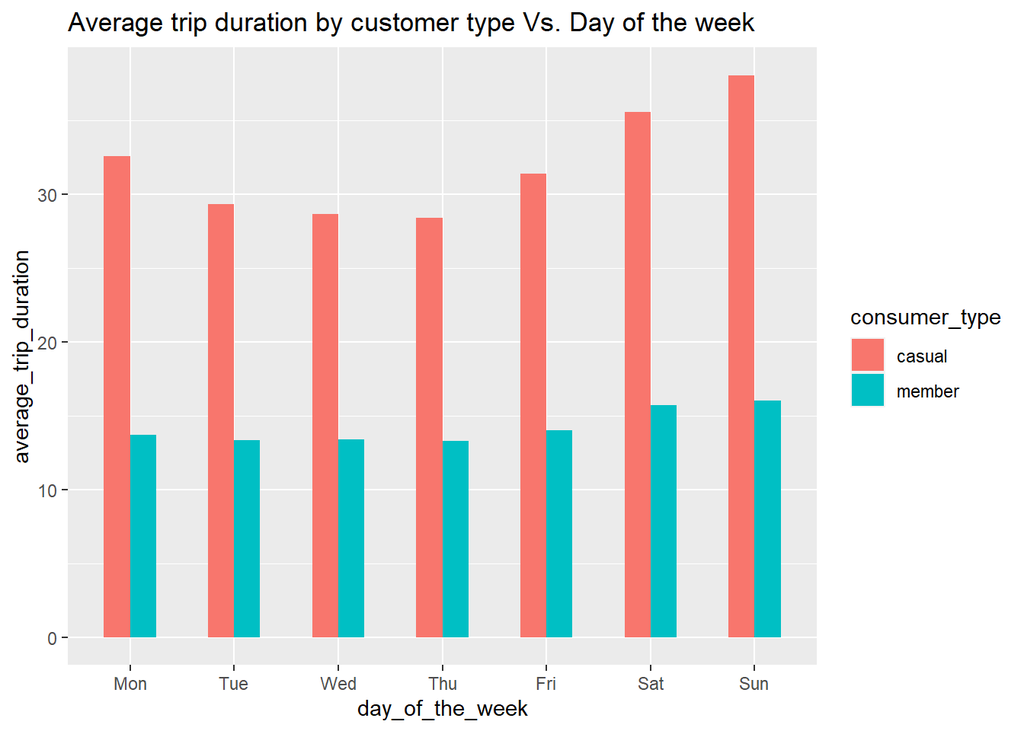

```r
combined_tripdata_v2 %>%
  group_by(consumer_type, day_of_the_week) %>%
  summarise(average_trip_duration = mean(trip_duration)) %>%
  ggplot(aes(x = day_of_the_week, y = average_trip_duration, fill = consumer_type)) +
  geom_col(width=0.5, position = position_dodge(width=0.5)) +
  labs(title ="Average trip duration by customer type Vs. Day of the week")
```

- From the above table and graph its clear that, the average trip duration of a casual rider is more than twice that of a member. Note that this necessarily does not mean that casual riders travel farther distance. It is also interesting to note that weekends not only contribute to more number of trips but also longer trips on average when compared to weekdays.

## Visualizaton of average trip duration by consumer type Vs. month.

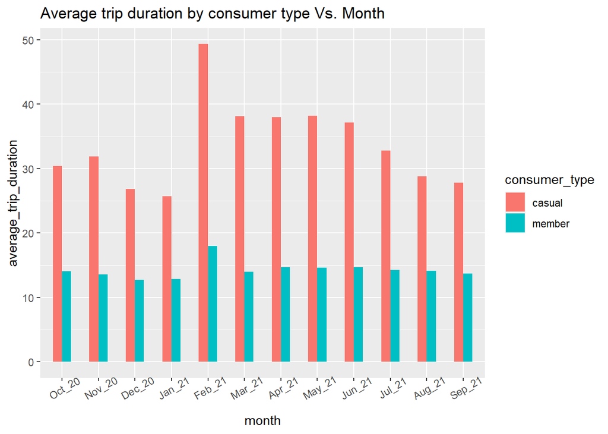

```r
combined_tripdata_v2 %>%
  group_by(consumer_type, month) %>%
  summarise(average_trip_duration = mean(trip_duration)) %>%
  ggplot(aes(x = month, y = average_trip_duration, fill = consumer_type)) +
  geom_col(width=0.5, position = position_dodge(width=0.5)) +
  labs(title ="Average trip duration by consumer type Vs. Month") +
  theme(axis.text.x = element_text(angle = 30))
```

#Anaysis + Average trip duration of member riders is anywhere between 10-15 minutes in the last 12 months i.e from Oct_20 to Sep_21, exception being observed on Feb_21 when it goes slightly over 15 minutes. However, there seems to be a distinct pattern when it comes to casual riders, whose average trip duration swings wildly from as low as ~25 minutes to max close to 50 minutes depending on time of the year. It is worth noting unusually long trip duration by casual riders in the month of Feb_21.

## Visualizaton of ride type Vs. number of trips by customer type

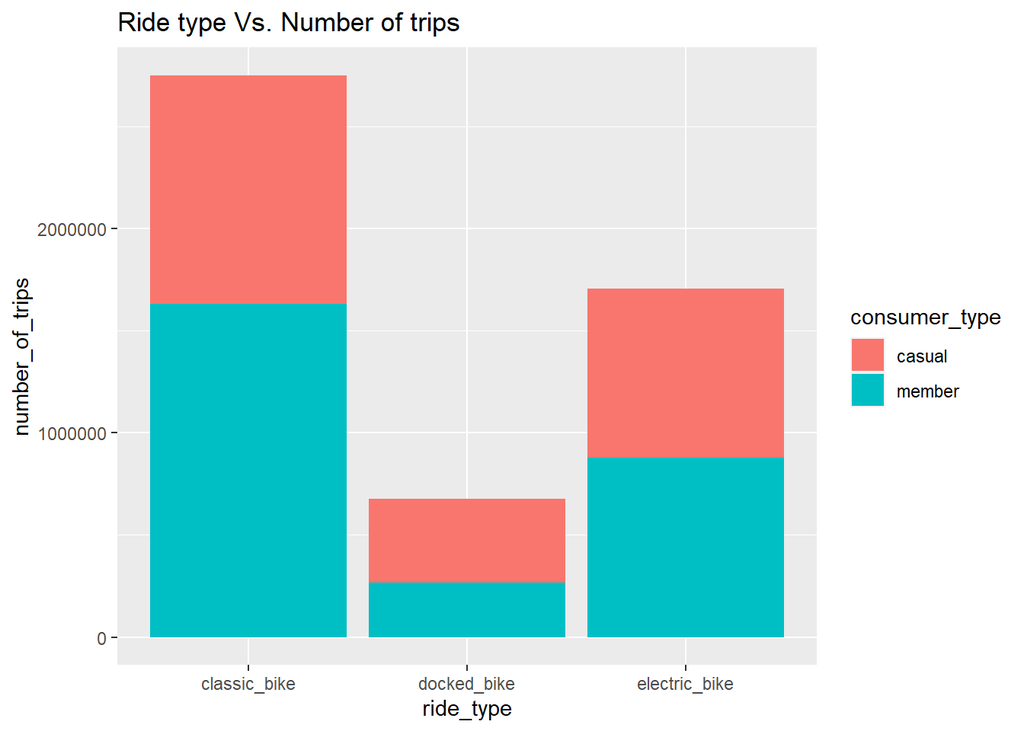

```r
combined_tripdata_v2 %>%
  group_by(ride_type, consumer_type) %>%
  summarise(number_of_trips = n()) %>%
  ggplot(aes(x= ride_type, y=number_of_trips, fill= consumer_type))+
  geom_bar(stat='identity') +
  scale_y_continuous(labels = function(x) format(x, scientific = FALSE)) +
  labs(title ="Ride type Vs. Number of trips")
```

#Creating a csv file of the clean data for futher analysis or visualizations in other tools like SQL, Tableau, Power BI, etc.

#Lets add new columns

```r
combined_tripdata_v2$yearly <- format(as.Date(combined_tripdata_v2$start_time),'%y')
```

```r
combined_tripdata_v3 <- combined_tripdata_v2 %>% mutate(started_at = mdy_hm(start_time), ended_at = mdy_hm(end_time))
combined_tripdata_v3$group_length <- case_when(combined_tripdata_v3$trip_duration < 30 ~ "Less than 30 minutes", combined_tripdata_v3$trip_duration < 60 ~"Less than 1 hour", combined_tripdata_v3$trip_duration <120 ~"Less than 2 hour", combined_tripdata_v3$trip_duration <480 ~"Less than 8 hour", combined_tripdata_v3$trip_duration <1440 ~"Less than 1 day", combined_tripdata_v3$trip_duration >=1440 ~"More than 1 day")
```

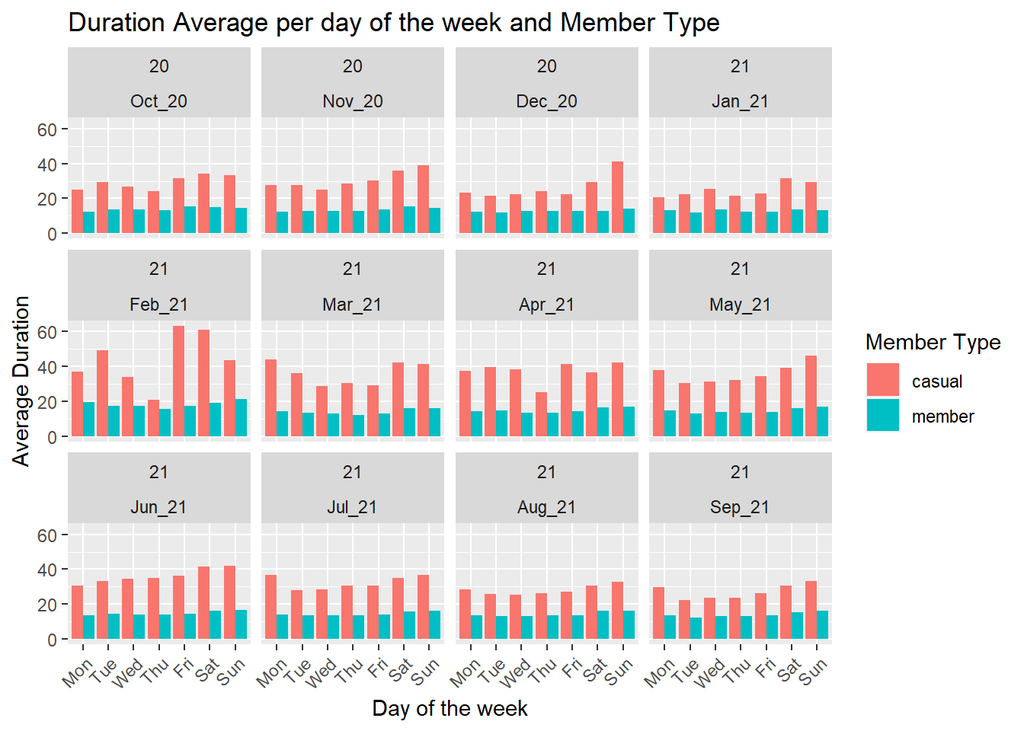

```r
summ_day_month_avg <- combined_tripdata_v3 %>%
  group_by(consumer_type,yearly,month, day_of_the_week) %>%
  summarise(number_of_rides = n() ,average_duration = mean(trip_duration), .groups = 'drop')
ggplot(summ_day_month_avg,aes(x = factor(day_of_the_week), y = average_duration, fill = consumer_type)) +
  geom_col(position = "dodge") +
  theme(axis.text.x = element_text(angle = 45, vjust = 1, hjust = 1)) + labs( x = "Day of the week", y = "Average Duration",
        title ="Duration Average per day of the week and Member Type", fill = "Member Type")  +
  facet_wrap(~yearly+month)
```

- Let’s check the trend for trips > 8 hours and trips < 8 hours.

[figure not shown]

```r
summ_avg_trip_more8 <-combined_tripdata_v3[!(combined_tripdata_v3$trip_duration>480),] %>%

  group_by(consumer_type, yearly, month, day_of_the_week) %>%
  summarise(number_of_rides = n() ,average_duration = mean(trip_duration), .groups = 'drop')

ggplot(summ_avg_trip_more8,aes(x = factor(day_of_the_week), y = average_duration, fill = consumer_type)) +
  geom_col(position = "dodge") +
  theme(axis.text.x = element_text(angle = 45, vjust = 1, hjust = 1,size=7)) +
  labs( x = "Day of the week", y = "Average Duration",
        title ="Duration Average per day, Month and Member Type",subtitle = "(Trips > 8 hours)", fill = "Member Type")  +
  facet_wrap(~yearly+month)
```

[figure not shown]

```r
summ_avg_trip_less8 <-combined_tripdata_v3[!(combined_tripdata_v3$trip_duration<480),] %>%

  group_by(consumer_type, yearly, month, day_of_the_week) %>%
  summarise(number_of_rides = n() ,average_duration = mean(trip_duration), .groups = 'drop')

ggplot(summ_avg_trip_less8,aes(x = factor(day_of_the_week), y = average_duration, fill = consumer_type)) +
  geom_col(position = "dodge") +
  theme(axis.text.x = element_text(angle = 45, vjust = 1, hjust = 1,size=7)) +
  labs( x = "Day of the week", y = "Average Duration",
        title ="Duration Average per day, Month and Member Type",subtitle = "(Trips < 8 hours)", fill = "Member Type")  +
  facet_wrap(~yearly+month)
```

```r
summ_final <- combined_tripdata_v3 %>% group_by(consumer_type) %>%
  summarise(count = n(),  min = min(trip_duration),Q1=quantile(trip_duration, probs = 0.25),median = median(trip_duration), mean = mean(trip_duration),
  Q3=quantile(trip_duration, probs = 0.75),Q4=quantile(trip_duration, probs = 0.99) , max = max(trip_duration),sd= sd(trip_duration))
summ_final
```

```
## # A tibble: 2 x 10
##   consumer_type   count   min    Q1 median  mean    Q3    Q4    max    sd
##   <chr>           <int> <dbl> <dbl>  <dbl> <dbl> <dbl> <dbl>  <dbl> <dbl>
## 1 casual        2356725     0  9.47   16.7  32.9  30.5 175.  55944. 261.
## 2 member        2775433     0  5.87   10.1  14.2  17.4  56.2  9558.  28.9
```

```r
clean_data <- aggregate(combined_tripdata_v2$trip_duration ~ combined_tripdata_v2$consumer_type + combined_tripdata_v2$day_of_the_week, FUN = mean)
write.csv(clean_data, "Clean Data.csv", row.names = F)
```

## 6. Act

- Final Conclusion based on analysis: Casual and annual members riding behavior is different

## How can team members and business act on these insights?

- Create a point rewarding system for casual riders and redeem those to avail discounts on becoming the annual members.
- Create a membership cards only for weekends.
- Create an advertisement during May-September month with discount to convert casual members to annual.
- Create an advertisement during Nov-Jan month to increase number of membership as during those month very low number of riding observed among both riders.
- Any additional data to expand the insights?: Weather data, Actual station names / zip code / Actual latitude and longitude.

## Resources

- Stack Overflow
- RDocumentation
- RStudio and Kaggle community

#——End of case study——